# Seattle Traffic Collisions and Correlations

Nessa Choi, Olivia Grillo, Christopher Petersen, Ethan Side

Autumn 2022

#### INFO-201: Technical Foundations of Informatics - The Information School - University of Washington

### Keywords:

Traffic, Car-Collisions, Weather, Transportation

## Introduction

Our project focuses on analyzing traffic collision data in the Seattle area. Our analysis includes investigating if and what possible correlations exist between traffic and location, weather, DUI collisions, and pedestrian/cyclist collisions. Our data sets include variables such as speed average, location, time stamp, injuries, fatalities, collision type, and other factors of car collisions. Investigating our datasets could raise questions about traffic-collisions in Seattle such as how certain weather conditions affect traffic, where the highest frequencies of collisions occur, and what type of crash is the most common.

## Problem Domain

**Framing:**

In a perfect world, traffic collisions would be a thing of the past, but they aren’t, and thousands of people still lose their lives every year. According to the World Health Organization, “Road traffic injuries are the leading cause of death for children and young adults aged 5-29 years.” We can take tangible steps in our local community to reduce traffic collisions, but first these steps rely on working with reliable data. Traffic collisions are an issue that affects everyone, knowing when and how they occur can help us make predictions and design decisions for a safer and more efficient future. The way Seattle is designed makes some roads and neighborhoods more prone to accidents, leading to unnecessary property damage, injuries, and even fatalities. This is an issue that has not only an economic burden but also a burden on human life. Socially and culturally we rely heavily on cars -especially on the west coast- and you can’t get to many places easily without a car. A reliance on car culture mixed with poor road design leads to more traffic collisions, burdening society with unnecessary economic and social damage. Government has a crucial role in lightening the burden of car centric infrastructure. Having precise data on traffic collisions allows government representatives, city planners, engineers, and designers to make more informed decisions about road layouts, traffic signals, and sign placement. It could also allow more careful policing of certain areas to predict and prevent accidents from occuring as well as allow quick reaction by first responders when they do. The data also makes a strong case for the development of better public transportation options which would reduce the economic burden of car ownership, the land requirements that car-culture necessitates, and the toll of life caused by traffic collisions.

**Direct and Indirect Stakeholders:**

Direct stakeholders include Engineers, city planners, policy makers, politicians, and first responders who deal with car accidents on a daily basis. The key indirect stakeholders are pedestrians and bikers who suffer the most from dangerous road design. Other indirect stakeholders include government officials and designers from other cities hoping to improve their transportation infrastructure.

**Human Values:**

The domain of this project primarily encompases two key values: Safety and community. Safety is one of the most important values for all people. When people have to risk their lives every day just to travel locally, their safety is at risk. By making decisions based on traffic data people’s safety could be greatly increased. We also want to look at how specific communities and neighborhoods are affected by heightened rates of traffic collisions on specific streets and intersections. We aim to investigate how the need for community is impeded by traffic collisions and how communities can be made closer with better road safety.

**Potential Benefits and Harms:**

**Possible benefits include:**

Safer roads, more efficient traffic, decreased fatalities and injuries from traffic collisions, enforcement of good driving habits, government transparency on traffic issues, increased public knowledge on the issue, push for better driving education.

**Possible harms include:**

Over-policing of certain areas, economic implications for companies related to car manufacturing and oil, priorities placed in certain neighborhoods where others are neglected, the data excludes car crashes that were not reported.

## Research Questions

**(1)** How does data about the weather conditions within the Greater Seattle Area correlate with the number of traffic collisions? People who are more aware of the correlations between weather and traffic collisions may be more aware and careful while driving and hopefully reduce the chance of getting into a collision themselves.

**(2)** Is there a correlation between where pedestrians and cyclists are involved in accidents? Do they tend to happen at intersections? And what percentage of accidents involve an innocent civilian?

**(3)** What hours/days have the highest risk of traffic collisions? We can use this data to advise safer driving habits or develop new technologies to deal with increased risk. This data can show the most dangerous time of day to be out. To see if more crashes happen during deemed “rush hours” or at night when drivers could be impaired.

**(4)** What areas had the highest rates of accidents where the driver was under the influence? Are there certain roads with significantly higher rates of DUI accidents? Policymakers and police can make decisions to redesign monitor areas with higher rates of DUI accidents. Better public transit options could be implemented as well to reduce the risk of DUI collisions.

## Expected Implications

If our research finds relationships between the listed causes and traffic collisions, officials should expect stronger laws and enforcement of speeding on roads, especially during hazardous weather. Alternatively, policymakers can try to emphasize the use of public transportation options, like the light rail in Seattle and bus routes in order to decrease the number of drivers on the roads. Traffic designers may examine the status of our roads and concerns in order to create more effective and safer roads, utilizing better materials and designs to enhance traffic safety and, as a result, reduce congestion and traffic collisions. Innovating new technologies that can assist drivers with safety alerts and weather advisories would be beneficial, as long as innovators are focused on safety or the people rather than an economic interest. Overall, we can expect that experts of all fields would take a look at our research and make decisions that would benefit the people and their safety in regards to traffic collisions.

## Limitations

Some limitations we want to focus on is staying within the Seattle area. If we were to focus on a larger/smaller location, then we might be overwhelmed or underwhelmed with the amount of data we find. Another limitation would be the mystery of whether the drivers involved with the collision data are Seattle residents or tourists. Some other limitations would include knowing whether the collision includes multiple cars, road closures during certain days/weeks, weather conditions from past weather data, and causes for collisions.

## The Dataset

**1)** Having the information on every traffic collision in the metro area paired with the Seattle weather patterns allows us to create datasets to reveal patterns in the traffic that can answer where, when, and why collisions are happening.  
**2)**

| Data File Name | Variables (columns) | Observations (rows) |
| --- | --- | --- |
| SDOT Collisions | Address Type, Collision Type, Light Condition, Location, Road Condition | Individual Collisions |
| Did it Rain in Seattle? | Max Temperature, Min Temperature, Precipitation In Inches, Did It Rain (True or False) | Date |
| Quarterly Vehicle Speed Report | Direction, Posted Speed, Month, Days of Data, Observed Vehicles, Volumes by Speed Bin | Samples 1-6, from January to March, going NB or SB on specified SR or Interstate |
| SeaTac, WA: Weather History | Time, Temperature (°F), Dew Point (°F), Humidity (%), Wind Speed (mph), Pressure (in), Precipitation (in) | Days of the month (1-31) |

**3)**  
Sdot Collisions - All years: City of seattle open data portal. Seattle Open Data. (2022, August 20). Retrieved October 30, 2022, from https://data.seattle.gov/dataset/SDOT-Collisions-All-Years/9jdj-3h57  
Tatman, R. (2017, December 20). Did it rain in Seattle? (1948-2017). Kaggle. Retrieved October 28, 2022, from https://www.kaggle.com/datasets/rtatman/did-it-rain-in-seattle-19482017?resource=download  
Quarterly Vehicle Speed Report. WSDOT. (2022, July 29). Retrieved October 31, 2022, from https://wsdot.wa.gov/about/transportation-data/travel-data/traffic-count-data/quarterly-vehicle-speed-report  
SeaTac, WA Weather History. Wunderground. (2014-2022). TWC Product and Technology. Retrieved October 31, 2022, from https://www.wunderground.com/history/monthly/us/wa/seatac/KSEA/date/2022-01  
**4)**  
1. Sdot Collisions: **(a)** The City of Seattle’s Department of Transportation has collected this data since 2004 and continues to actively update this information every few weeks. This is collected as a resource that takes part in the City of Seattle’s Open Data Portal where information regarding the city like businesses, communities, permits, education, and transportation are published for public knowledge. **(b)** This data collection effort is funded by the city and of which benefits the city and the people of Seattle. **(c)** The website is viewable by anyone, but the data is accessible and modifiable by users who have the credentials to do so via login. The data is credible because it is published by the SDOT officials themselves, and published on the official SDOT website. **(d)** We obtained the data by searching for the City of Seattle records of traffic collisions through a search engine and are choosing to credit the source of the data for our project.  
2. Did it rain in Seattle: **(a)** This dataset regarding rain in Seattle was collected by Rachael Tatman in 2017 for the purpose of compiling weather data of nearly 70 years into one large dataset. **(b)** This collection of data was taken from the Seattle-Tacoma International Airport by NOAA. A benefit of this data for the airport is to know the trends in weather so they can plan accordingly for flights coming in and out of Seattle. It would also be a benefit to any citizen who is planning on moving to Seattle to see exactly how much precipitation occurs on a day to day basis. ** **(c)** NOAA is a trusted government agency whose tracking of weather spans decades and has the most up to date tools for tracking weather patterns in the country. **(d)** To obtain the data we searched precipitation in Seattle, WA. Kaggle is a trusted website to obtain datasets that can be difficult to find on their home website but by having the NOAA credit for the data itself it makes the data trustworthy as we have the ability to check the NOAA data to cross check and make sure Rachael Tatman transferred the data correctly.  
3. Quarterly Vehicle Speed Report: **(a)** Washington State’s Department of Transportation has collected this data from 2013 to 2020 and continues to update their speed reports in their own database system since 2021. As quoted on the website, WSDOT states that “This data may be used to evaluate vehicle speed trends to assist in highway design and safety improvements” as their reason for collecting and publishing this data. **(b)** The data collection effort was funded by the state of Washington which benefits the state and the people of Washington. **(c)** The data is only accessible by WSDOT officials and is recorded via WSDOT’s “network of traffic recorders permanently installed in Washington State highways”. **(d)** We obtained this data by looking through the WSDOT website that publishes transportation data, which includes information like crash data, roadway data, and travel data. We decided to cite and credit this source for our project.  
4. SeaTac, WA Weather History: **(a)** This data is collected by the [WSDOT Weather Data from the Seattle-Tacoma International Airport Weather Station] (https://wsdot.com/travel/real-time/weather/1879) and published by Weather Underground daily. This is for the purpose of having a consistent and cohesive dataset of weather data and having access to weather historical data. This weather data is also helpful for determining and sending accurate weather alerts to residents of Washington state, if caution is advised. **(b)** The data collection effort is funded by WSDOT and benefits the residents of Washington in regards to knowing the current state of weather conditions. **(c)** This data is validated by WSDOT but also by The Weather Company, who owns Weather Underground and Weather.com. The Weather Company is also a weather forecasting and information technology company by IBM, which is also very secure. **(d)** We obtained this data from searching for weather datasets in search engines. We have decided to credit this source in support of the other weather dataset from Kaggle, in the case that we need more recent weather data.

## Summary Paragraph

Our data set presents incidences of car accidents in Seattle, Washington. With 192988 observations (rows) and 18 variables (columns), our data set allows us to examine these specific details of each accident:Date, Latitude, Longitude, Location, Forecast, Raining, Precipitation (inches), Minimum Temperature (F), Maximum Temperature (F), Light Conditions, Road Conditions, Injuries, Serious Injuries, Fatalities, Pedestrians Involved, Cyclists Involved, Driver Speeding, DUI. Our data set ranges from the date 2004-01-01 to 2017-12-14.

## Aggregate Data Table

[output not shown]

We included this table as an easy way to view the most dangerous streets in the Seattle area. By getting cumulative totals of fatalities, injuries, serious injuries, and accidents where pedestrians or cyclists were involved and by arranging from highest to lowest one can quickly identify problem areas.

## Charts

### Map of locations in Seattle with 6 or more DUI Accidents:

[interactive chart not shown]

### Scatterplot of Total Accidents, Injuries, and Fatalities to Amount of Precipitation:

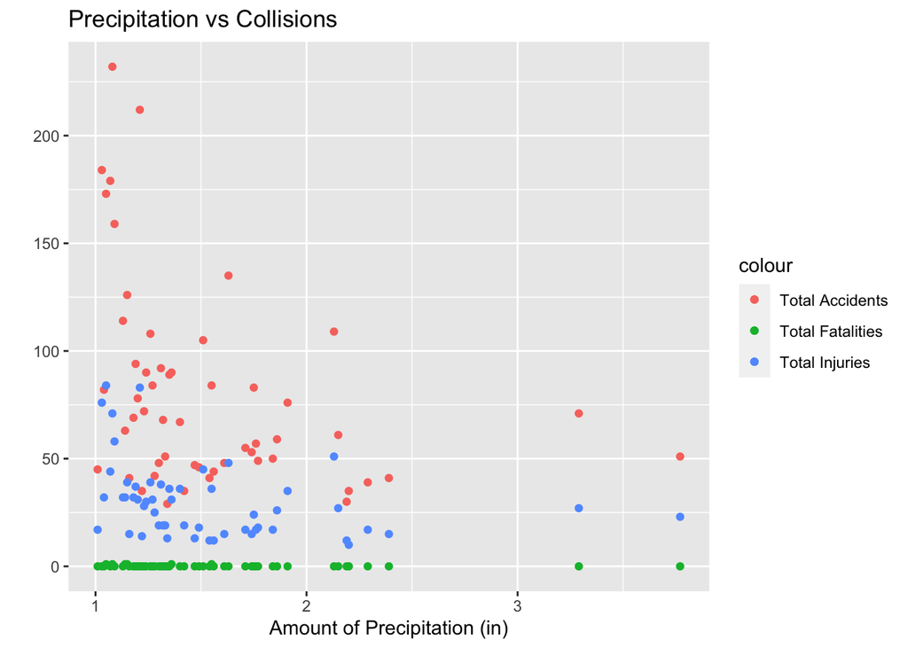

## Acknowledgements

Thank you Raina for answering our questions during section and being a great resource for us when we need assistance.

## References

System, S. (2021, March 24). 5 cost-effective ways to reduce traffic crashes. Fleet Safety Training Blog. Retrieved October 31, 2022, from https://blog.drivedifferent.com/blog/5-cost-effective-ways-to-reduce-traffic-crashes Quarterly Vehicle Speed Report. WSDOT. (2022, July 29). Retrieved October 31, 2022, from https://wsdot.wa.gov/about/transportation-data/travel-data/traffic-count-data/quarterly-vehicle-speed-report Sdot Collisions - All years: City of seattle open data portal. Seattle Open Data. (2022, August 20). Retrieved October 30, 2022, from https://data.seattle.gov/dataset/SDOT-Collisions-All-Years/9jdj-3h57 SeaTac, WA Weather History. Weather Underground. (2014-2022). TWC Product and Technology. Retrieved October 31, 2022, from https://www.wunderground.com/history/monthly/us/wa/seatac/KSEA/date/2022-01 Steinger, M. (2022, June 3). The 12 Most Common Causes of Car Accidents. Personal Injury Attorneys: Steinger, Greene and Feiner. Retrieved October 31, 2022, from https://www.injurylawyers.com/blog/common-causes-car-accidents/ Tatman, R. (2017, December 20). Did it rain in Seattle? (1948-2017). Kaggle. Retrieved October 28, 2022, from https://www.kaggle.com/datasets/rtatman/did-it-rain-in-seattle-19482017?resource=download WSDOT. (n.d.). Seattle, Seattle-Tacoma International Airport: Current Weather. Washington State Department of Transportation. Retrieved October 31, 2022, from https://wsdot.com/travel/real-time/weather/1879